# Tuango - Targeting Mobile App Messages

### Question 14

Create a bar chart with profit information for the analyses conducted in questions 12 and 13

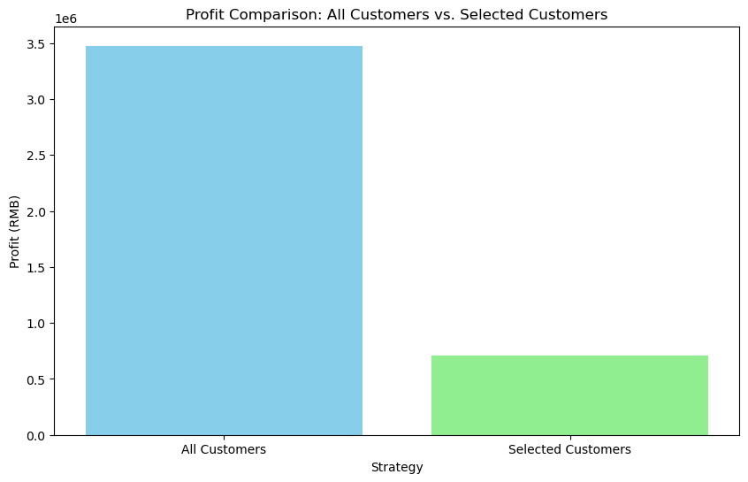

```python
import matplotlib.pyplot as plt
# Data for profit comparison
profits = {
    "All Customers": 3476160.3,
    "Selected Customers": 712678.524
}

# Creating the bar chart
plt.figure(figsize=(10, 6))
plt.bar(profits.keys(), profits.values(), color=['skyblue', 'lightgreen'])

# Adding titles and labels
plt.title('Profit Comparison: All Customers vs. Selected Customers')
plt.ylabel('Profit (RMB)')
plt.xlabel('Strategy')

# Showing the bar chart
plt.show()
```

### Question 15

Create a bar chart with ROME for the analyses conducted in questions 12 and 13

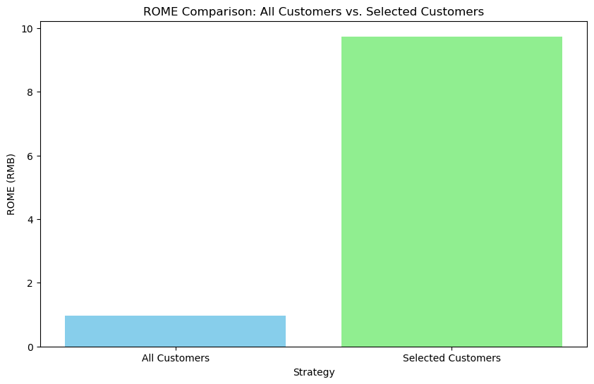

```python
import matplotlib.pyplot as plt
# Data for profit comparison
ROME = {
    "All Customers": 0.9722796444909866,
    "Selected Customers": 9.736444444444444
}

# Creating the bar chart
plt.figure(figsize=(10, 6))
plt.bar(ROME.keys(), ROME.values(), color=['skyblue', 'lightgreen'])

# Adding titles and labels
plt.title('ROME Comparison: All Customers vs. Selected Customers')
plt.ylabel('ROME (RMB)')
plt.xlabel('Strategy')

# Showing the bar chart
plt.show()
```

### Question 16

You also have access to a dataset with the results from the deal offer roll-out (tuango_post.parquet). Tuango decided to contact all remaining 397,252 customers because this would provide data that could be used to evaluate different targeting approaches. The data has a "test" variable (test = 1 for the data used in the test, test = 0 for the remaining customers). You can use this variable to help evaluate the actual performance for the targeting approaches evaluated in questions 12 and 13. Re-create the plots from question 14 and 15 based on this new dataset.

Copy your tuango-pre.ipynb file to a new file tuango-post.ipynb. Instead of using the tuango_pre.parquet data, load tuango_post.parquet. You should be able to re-use most of your code and text. Calculate the actual performance for both targeting approach on the 'roll out' sample (i.e., test == 0).

Hint 1: It is important that you do NOT use any information about buyers that were in the 'roll out' sample (i.e., test == 0) when calculating the break-even response rate etc. for targeting.

Hint 2: You have the actual data on what happened in the "post" data. Use that information to calculate performance (i.e., do not "project" the performance like you had to do for questions 12 and 13).

### Question 17

Please describe how you used Generative AI-tools like ChatGPT to support your work on this assignment. Provide pdfs and/or screenshots of your “discussions” with these tools and comment on what things did and did not go well. Also add any questions you may have about the assignment and the support you received from GenAI so we can discuss these topics in class.

Note: No matter how you used Generative AI-tools, you will be expected to fully understand all elements of the assignment. You may be called on in class to walk us through your thought process and how different parts of your code work.